## Cabdal

Creem la matriu de disseny i hi afegim la resposta:

```r
library(FrF2)
design = FrF2(nruns = 8,  nfactors = 3,
              factor.names = c("caudal", "intensidad", "velocidad"),
              randomize = FALSE)

calidad = c(10.5, 26, 13.5, 19, 12, 25.5, 16, 21.5)
design = add.response(design, calidad)
```

Fem un Daniel plot, on hi identifiquem el cabdal i la interacció cabdal-intensitat com a importants.

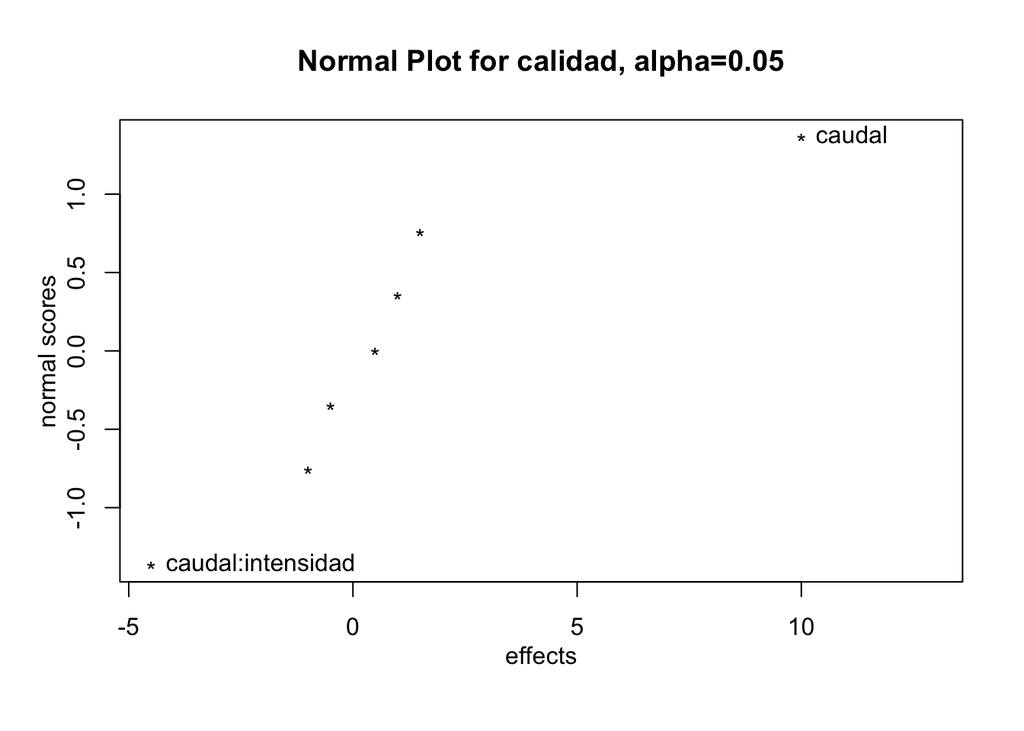

```r
DanielPlot(design)
```

Ajustem el model i mirem el gràfic de mitjanes estimades

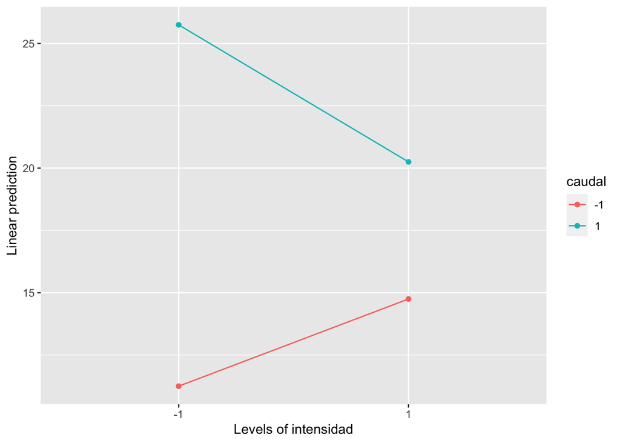

```r
library(emmeans)
mod = aov(calidad ~ caudal+caudal*intensidad, data = design)
emmip(mod, caudal ~ intensidad)
```

Com que l’objectiu és maximitzar la qualitat, volem que la intensitat sigui 230A (-1) i el cabdal 12 l/min (+1). Si volem continuar experimentant, podríem provar valors més baixos d’intensitat i més alts de cabdal.

## Volants

Creem la matriu de disseny i hi afegim la resposta:

```r
disseny = FrF2(nruns = 8, nfactors = 3, replications = 2, randomize = FALSE,
                factor.names = c("P", "R", "T"))
duresa = c(35, 62, 28, 55, 49, 48, 34, 45, 18, 47, 31, 56, 26, 31, 39, 44)
disseny = add.response(design = disseny, response = duresa)
```

Aquí tenim dues rèpliques per condició experimental. Podem ajustar el model amb totes les interaccions i treure’n $p$-valors:

```r
mod = aov(duresa ~ P*R*T, disseny)
summary(mod)
```

```
##             Df Sum Sq Mean Sq F value  Pr(>F)
## P            1   1024  1024.0  11.977 0.00856 **
## R            1     16    16.0   0.187 0.67674
## T            1     16    16.0   0.187 0.67674
## P:R          1      4     4.0   0.047 0.83417
## P:T          1    484   484.0   5.661 0.04460 *
## R:T          1      0     0.0   0.000 1.00000
## P:R:T        1     16    16.0   0.187 0.67674
## Residuals    8    684    85.5
## ---
## Signif. codes:  0 '***' 0.001 '**' 0.01 '*' 0.05 '.' 0.1 ' ' 1
```

Si anem extraient variables amb el $p$-valor més gran una a una fent servir l’algorisme descrit a les transparències de classe, ens quedem amb un model amb P i P*T:

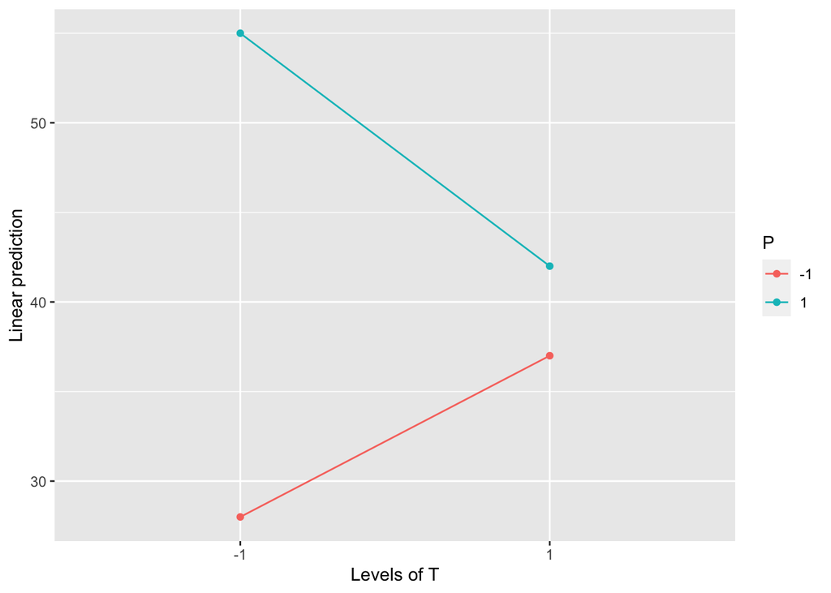

```r
mod_final = aov(duresa ~ P + P*T, disseny)
emmip(mod_final, P ~ T)
```

Hi ha una interacció entre P i T: quan P és al seu nivell baix (-1), l’efecte de T és positiu, mentre que quan P és al seu nivell alt (+1), l’efecte de T és negatiu.

Ara refem l’anàlisi afegint-hi W, la setmana.

```r
disseny = FrF2(nruns = 16, nfactors = 4,randomize = FALSE,
                factor.names = c("P", "R", "T", "W"))
disseny = add.response(design = disseny, response = duresa)
```

Ara no tenim multiples rèpliques ($r = 1$). Fem un Daniel plot, doncs.

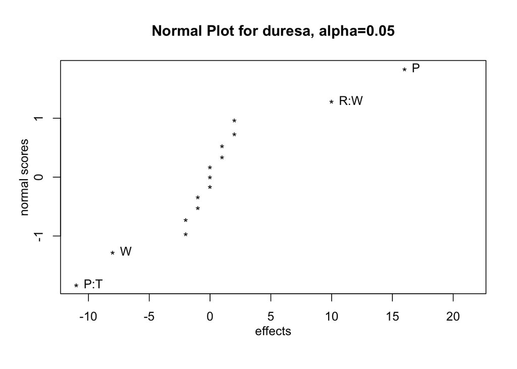

```r
DanielPlot(disseny)
```

Ajustem el model amb les variables importants i fem un `emmip` per entendre l’efecte de les variables:

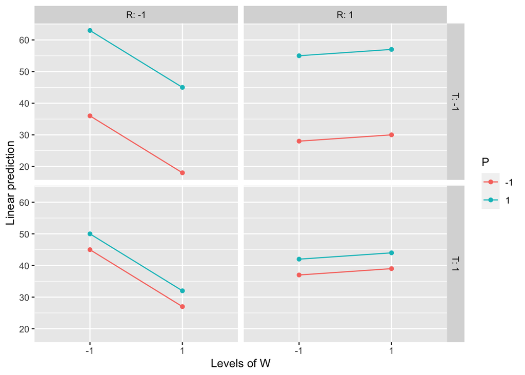

```r
mod = aov(duresa ~ P + W + R*W + P*T, disseny)
emmip(mod, P ~ W | T + R, facetlab = "label_both")
```

Vist el gràfic, recomanaria T = 1 i R = 1. En aquestes condicions, l’efecte de W, que té a veure amb la meteorologia, és mínim. A més, les mitjanes estimades no són ni massa grans ni massa petits, comparant-les amb les altres (que era el que volíem).

## Jersei

La part davantera d’un jersei cordat està formada per 2 meitats, i cadascuna d’elles està formada al seu torn pel que anomenem cos i tira. La tira és la zona on van allotjats els botons o els traus (segons el costat) i està teixida de manera que és més forta i consistent que el cos.

Tradicionalment, el cos i la tira es teixien per separat i després es cosien, però en l’actualitat hi ha màquines que teixeixen simultàniament, en una mateixa peça, el cos i la tira, amb l’avantatge que s’eliminen operacions en la confecció de la peça.

L’inconvenient és que en tenir la tira diferent tipus de punt, i estar teixida sota altres paràmetres, de vegades resulta ser més llarga o més curta que el cos, de manera que la peça resulta defectuosa.

Per determinar les condicions de teixit de la tira que aconsegueixen que la longitud del cos (LC) i de la tira (LT) siguin iguals, es realitza un disseny $2^3$ amb els següents factors:

- A: Tipus de tira: Interlock (–) i tubular (+)
- B: Número d'agulles: 4 i 10
- C: Graduació del punto (longitud de la malla a la part interior): 9,0 i 10,8

S'obtenen els següents resultats, en l'ordre estàndard de la matriu de disseny:

```r
lc = c(67.8, 71.7, 67.6, 77.0, 62.2, 71.6, 71.7, 75.6)
lt = c(62.6, 66.8, 62.6, 71.7, 61.1, 66.8, 70.6, 70.6)
```

Temps que es triga en fer la peça (t, mm:ss): 9:18 9:18 9:17 9:18 12:40 12:39 12:39 12:39

1. Expliqueu com influeixen cadascun dels factors en el temps que triga a teixir-se la peça

**Solució:** Convertim els temps a segons

```r
temps = c(9*60+18, 9*60+18, 9*60+17, 9*60+18,
          12*60+40, 12*60+39, 12*60+39, 12*60+39)
```

És un disseny $2^3$. Creem la matriu de disseny amb `FrF2` , afegim la resposta, i fem el Daniel plot. L’únic efecte important és el de la graduació: el procés és molt més lent quan la graduació és “gran”.

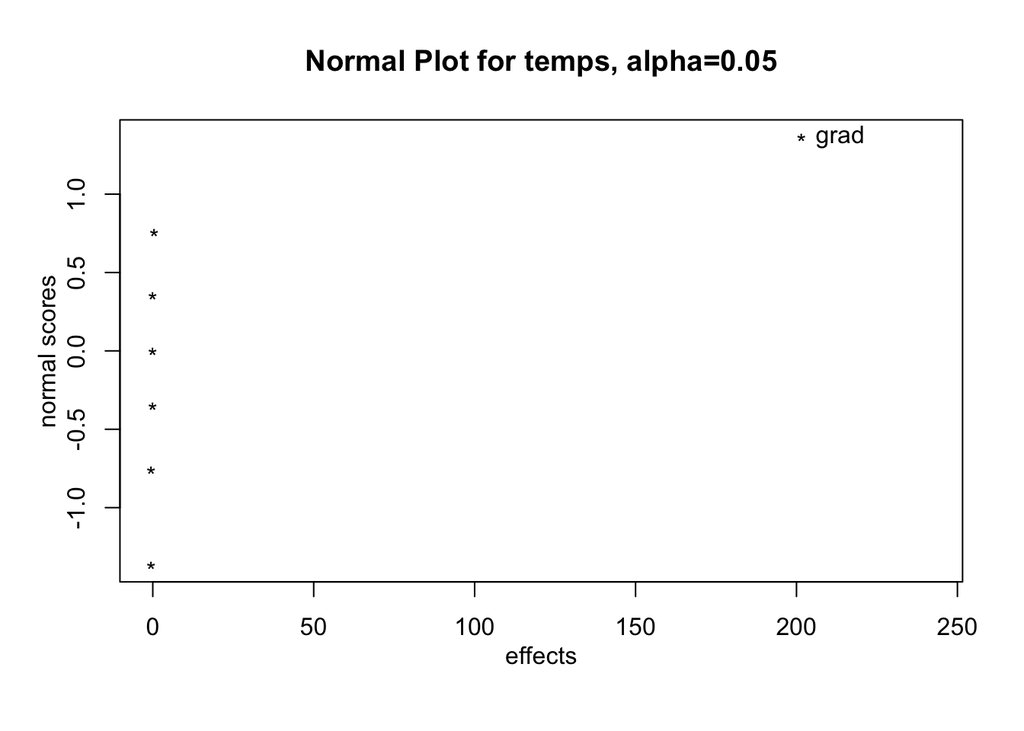

```r
library(FrF2)
disseny = FrF2(nruns = 8, nfactors = 3,
               factor.names = c("tipus", "agulla", "grad"),
               randomize = FALSE)
dis_temps = add.response(disseny, temps)
DanielPlot(dis_temps)
```

2. Tenint en compte que l’objectiu és que LC = LT (no importa el valor concret que prenguin), indiqueu quina penseu que ha de ser la resposta a analitzar

**Solució:** La diferència LC-LT és una bona opció.

```r
dif = lc-lt
```

3. Identifiqueu els efectes importants i expliqueu com influeixen els factors en la resposta.

**Solució:** Creem el disseny amb `dif` com a resposta i mirem el Daniel plot. Identifiquem el tipus, la graduació i la seva interacció com a importants.

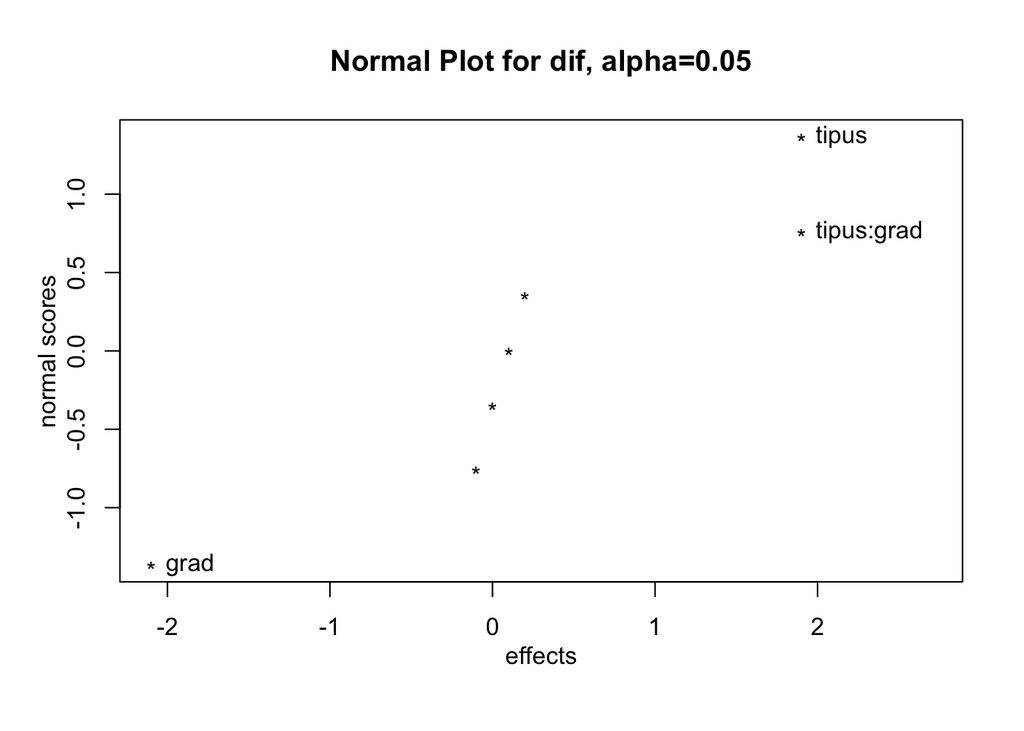

```r
dis_dif = add.response(disseny, dif)
DanielPlot(dis_dif)
```

Fem la taula ANOVA i veiem que tot és significatiu.

```r
mod_dif = aov(dif ~ tipus + tipus*grad + grad, dis_dif)
summary(mod_dif)
```

```
##             Df Sum Sq Mean Sq F value   Pr(>F)
## tipus        1   7.22    7.22   240.7 0.000101 ***
## grad         1   8.82    8.82   294.0 6.79e-05 ***
## tipus:grad   1   7.22    7.22   240.7 0.000101 ***
## Residuals    4   0.12    0.03
## ---
## Signif. codes:  0 '***' 0.001 '**' 0.01 '*' 0.05 '.' 0.1 ' ' 1
```

Mirem el gràfic d’efectes i la taula d’efectes estimats

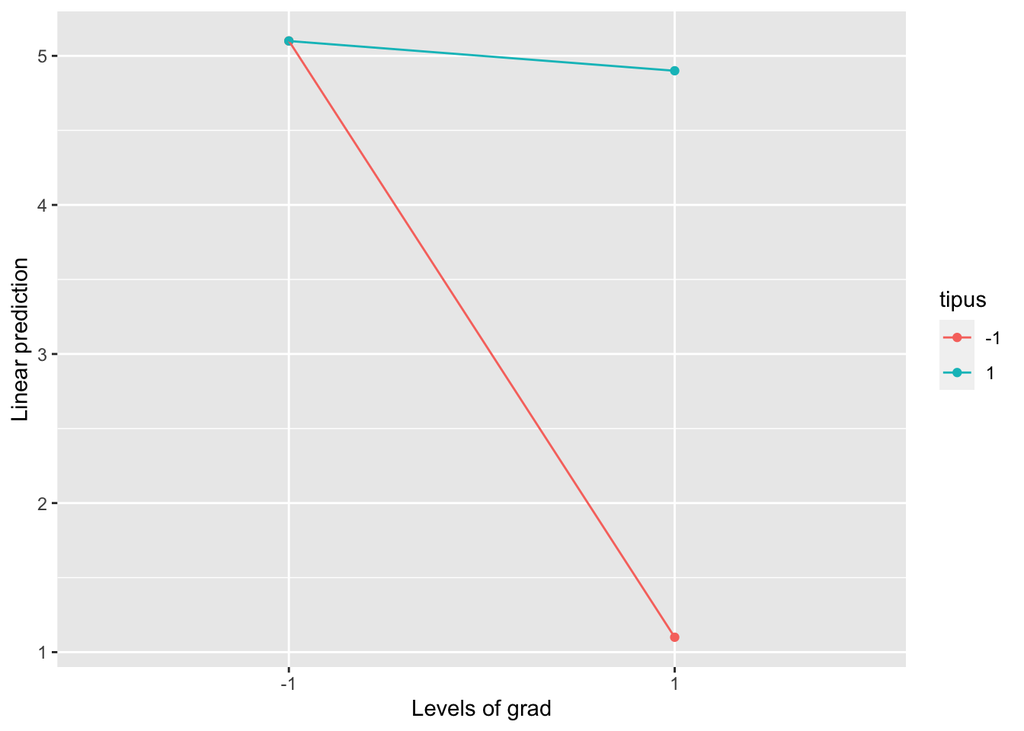

```r
library(emmeans)
emmip(mod_dif, tipus ~ grad)
```

```r
emmeans(mod_dif, ~ grad*tipus)
```

```
##  grad tipus emmean    SE df lower.CL upper.CL
##  -1   -1       5.1 0.122  4     4.76     5.44
##  1    -1       1.1 0.122  4     0.76     1.44
##  -1   1        5.1 0.122  4     4.76     5.44
##  1    1        4.9 0.122  4     4.56     5.24
##
## Confidence level used: 0.95
```

Hi ha una clara interacció. L’efecte de la graduació depèn clarament del tipus.

4. En cas que poguéssiu continuar l’experimentació, indiqueu com ho faríeu.

**Solució:** Donat que la graduació és una variable numèrica, intentaria seguir pujant el seu valor per veure si trobem una diferència de 0. Fixaríem el tipus a “Interlock”.

5. Es pot aconseguir l’objectiu que LC = LT? És possible aconseguir-ho amb un temps de teixit inferior a 10 minuts? Raoneu la resposta.

**Solució:** No ho podem saber segur… Res no ens garanteix que, si seguim pujant la graduació, la diferència baixarà fins a 0. Donat l’efecte de la graduació sobre la resposta descrit a la primera part, sembla poc probable que trobem LT = LC amb un temps de teixit inferior a 10 minuts.